# BREVE ANÁLISE DOS DADOS DO SERVIÇO SMP (TELEFONIA CELULAR)

24 de outubro de 2018

## Objeto

Essa análise objetiva estudar os dados do serviço móvel pessoal- SMP, coletados no Portal Anatel, por meio da abordagem dos seguintes tópicos:

1. Análise dos dados de avaliação da percepção dos usuários em relação ao funcionamento do serviço SMP;
2. Análise da correlação entre a infraestrutura das operadoras e a nota de percepção recebida;
3. Análise da quantidade de linhas de celular e a população e a sua distribuição regional.

## Objetivos

- Verificar de forma regionalizada quais foram as operadoras melhores avaliadas no quesito "funcionamento do serviço de celular" na Pesquisa de satisfação da qualidade percebida, realizada anualmente pela Anatel.
- Investigar se as notas obtidas na pesquisa têm alguma correlação com a infraestrutura que as operadoras têm nos respectivos Estados. Em teoria a tendência é que quanto mais antenas disponíveis uma operadora possui, melhor é o sinal e a experiência do usuário no serviço.
- Cruzar os dados da população brasileira com os dados de quantidades de linhas habilitadas e verificar a sua distribuição e a proporção de linhas por habitantes de forma regionalizada.

## Contexto

Desde 2015 a Agência Nacional de Telecomunicações promove a aferição do Grau de Satisfação e da Qualidade Percebida junto ao Usuários de Serviços de Telecomunicações.Isso é feito por meio de uma pesquisa cujo população-alvo é composta por todos os usuários do serviço, com idade mínima de 18 (dezoito anos), na condição de principal usuário, com registro em nome de pessoa física e residentes de todas as Unidades da Federação (UF), as notas variam de 0 "totalmente insatisfeito") a 10 ("totalmente satisfeito").

A pesquisa mede diversos aspectos e serviços de telefonia, no entanto nesse estudo foi selecionada apenas a nota para o quesito funcionamento do serviço de celular. Na pesquisa as notas foram divididas entre linhas pré e pós pagas. Para o estudo foi considerado o serviço como um todo, sendo a nota utilizada a média obtidas nas duas modalidades.

Além dessa pesquisa, a Anatel coleta mensalmente diversos dados que são disponibilizados em sua página na Internet. Para o estudo foram selecionados os dados de Acessos do SMP dos últimos 3 anos, que significa a quantidade de usuários do serviço e os dados de infraestrutura, onde estão disponíveis diversas informações técnicas sobre as ERBS-estação rádio Base e as antenas que nela são instaladas por cada entidade outorgada.

Nesse trabalho foram selecionado para estudo apenas os dados das 4 maiores operadoras do país, por possuirem atuação em todo território nacional, respectivamente a CLARO, a OI, a TIM e a VIVO.

## Método

Primeiramente foram obtidos os dados de Infraestrutura ([Portal Anate - Infraestrutura - Telefonia Móvel)](https://sistemas.anatel.gov.br/se/public/view/b/licenciamento.php).

Foi necessário realizar 27 extrações de tabelas CSV contendo os dados técnicos da infraestrutura das operadoras, uma para a cada Estado da Federação. Nessas tabelas CSV, nomeadas respecticvamente de UF-csv_licenciamento, cada linha do arquivo corresponde a uma antena, desse modo para saber a quantidade de antenas disponíveis por Operadora em cada Estado foi contada a quantidade de linhas filtradas por operadora.

Ao final foram gerados 27 data.frame, que foram unidos por meio da função full_join e deu origem ao Data.Frame "Antenas", contendo a UF, a Operadora e a suas respectivas quantidade de antenas.

Em seguida foi trabalhado os dados de acessos, obtidos em ([Portal Anatel - TELEFONIA MÓVEL - ACESSOS)](https://cloud.anatel.gov.br/index.php/s/TpaFAwSw7RPfBa8?path=%2FMovel_Pessoal).

O CSV Acessos_SMP_2015-2018_-_Total possui a informação da quantidade de linhas dos 3 últimos anos, por Estado e por empresa, além de dados das tecnologias e velocidades da internet móvel.

No estudo os dados foram filtrados e sumarizados para gerar o Data.Frame "Acessos", contendo a UF, a Operadora e a quantidade de acessos do último mês disponível, no caso agosto de 2018.

Por conseguinte, os Data.Frame Antenas e Acessos foram unidos e deram origem ao Data.Frame SMP, contendo os dados de UF, Operadora, Quantidade de Acessos e a Quantidade de antenas.

Em adição, foi gerado manualmente o vetor Notas, com as notas extraídas do último relatório da pesquisa de satisfação.([Portal Anatel-Satisfação e Qualidade Percebida - 2017)](http://www.anatel.gov.br/consumidor/pesquisa-de-satisfacao-e-qualidade/2017). Esses dados estão disponíveis apenas em forma de relatório no Portal da Agência , assim não foi possível sua inserção por meio importação do Dataset. Esse vetor foi inserido ao Data.Frame "SMP".

Para a apresentação gráfica o número de antenas foi comparado previamente ao número de clientes de cada operadora por estado da Federação. Assim, foi obtido a quantidade média de usuários por antena.

No segundo segmento foi criado o Data.Frame "SMP_POP, que foi originado a partir do Data.Frame SMP sumarizado por UF. Nele foi acrescentado manualmente um vetor com a População dos Estados brasileiros retirados do último senso do IBGE ao Data.Frame SMP. Em seguida foi acrescida uma coluna com a proporção de linhas de celular por habitantes.

Para apresentação gráfica, o SMP_POP foi divido por Região (Norte, Nordeste, Centro-Oeste, SUl e Sudeste) para melhor representar a proporção. Assim, foram criados 5 novos Data.Frame com os dados sumarizados pelas respectivas Regiões, contendo a quantidade de linhas, de habitantes e a proporção da Região.

## Gráfico 1

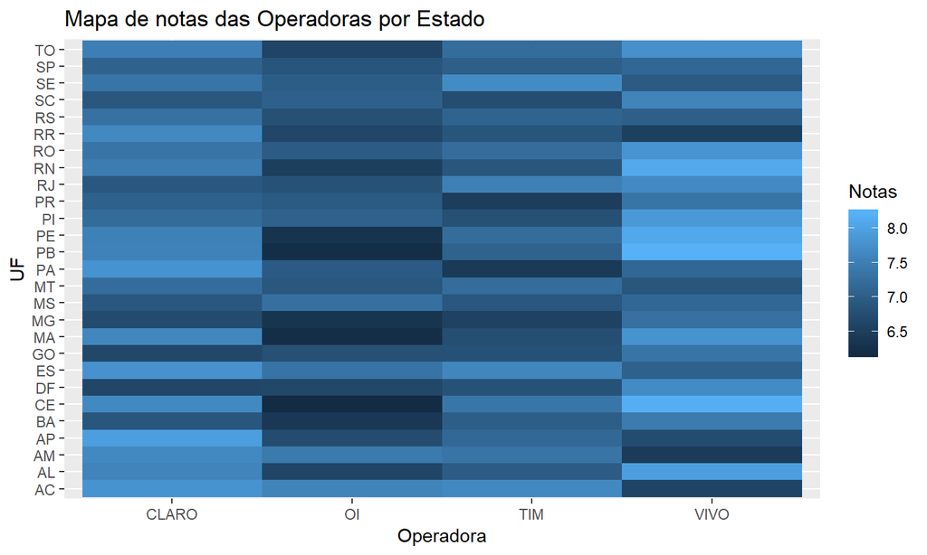

## Gráfico 2

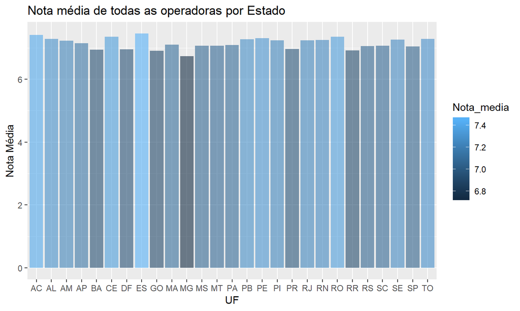

## Gráfico 3

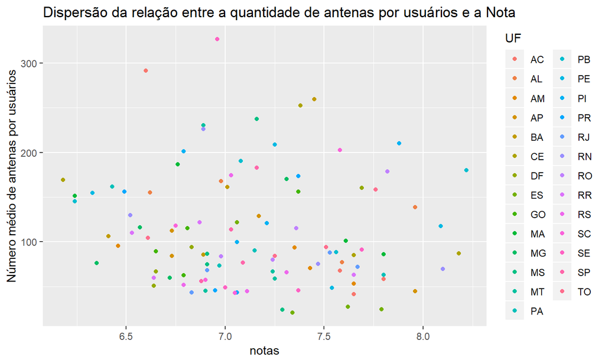

## Gráfico 4

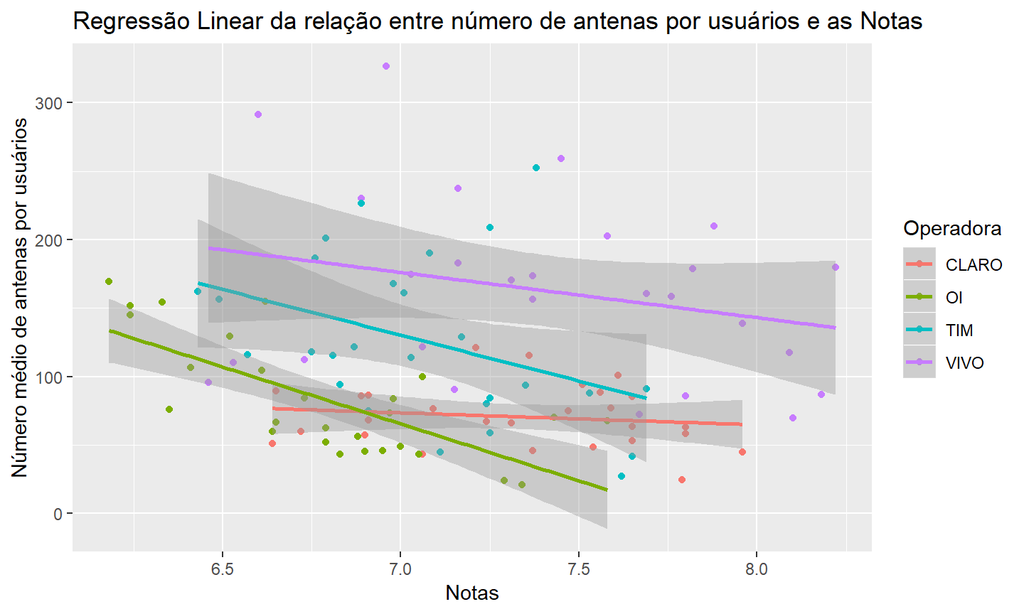

## Gráfico 5

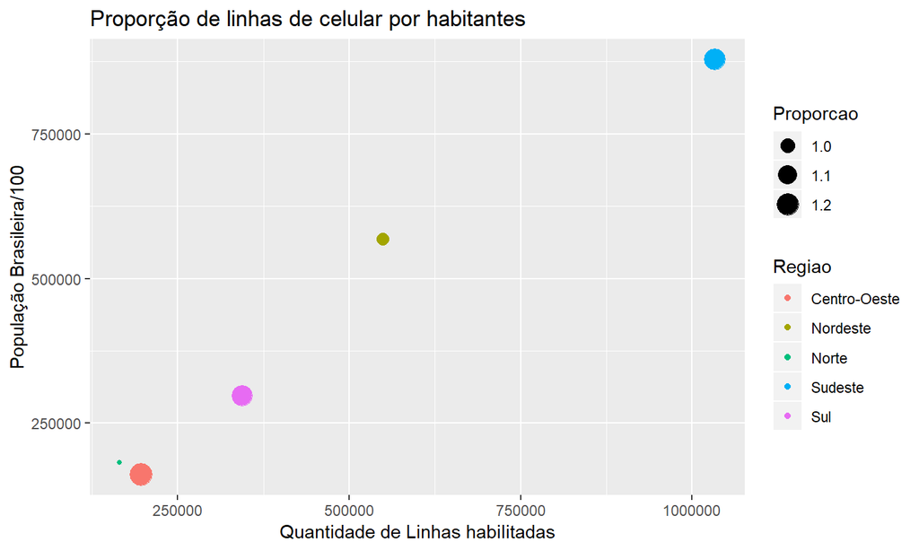

## Conclusão

- Gráfico 1: Mapa de notas das Operadoras por Estado - A primeira análise buscou visualizar como as notas de cada Operadora estavam distribuídas nos Estados. Pelo mapa das cores é possível perceber que a OI mostra um número mais acentuado de avaliações baixas. Enquanto a Vivo aparenta ser a melhor avaliada no quesito funcionamento do serviço de celular.
- Gráfico 2: Nota média obtida pelas Operadoras por Estado - Na segunda análise foi feita um extração da média das notas de todas as Operadoras por Estado. Por conseguinte, o Estado de Minas Gerais apresentou as menores médias de notas, o que denota que a percepção dos usuários quanto ao funcionamento do serviço de celular não está boa, comparada aos demais Estados da Federação.

Em contrapartida, os usuários do Espirito Santos demostraram estar satisfeitos com o Funcionamento do SMP no Estado, uma vez que foi o Estado onde as Operadoras tiveram a maior média geral na avaliação.

- Gráfico 3: Dispersão da relação entre a variável Quantidade de antenas por assinante e a Nota recebida na pesquisa de qualidade - Nessa análise buscou se estudar se a nota obtida pela operadora tinha relação com a sua infraestrutura. Conforme verifica-se no gráfico 3 a dispersão obtida não permite afirmar haver uma correlação positiva entre essas duas variáveis.
- Gráfico 4: Regressão Linear da relação entre número de antenas por usuários e as Notas - Nesse gráfico foi inserida uma linha de regressão linear para cada Operadora. O resultado visualizado no gráfico mostra uma correlação negativa entre a quantidade média de usuários por antenas e as Notas obtidas.

O resultado evidenciou não haver relação positiva direta entre a infraestrutura da operadora e a percepção que seu usuário tem do seu serviço, considerando apenas esse aspecto da quantidade de antenas.

- Gráfico 5: Proporção de linhas de celular por habitantes - Na segunda parte do estudo foi analisada a proporção de celular por habitante. Por meio do Gráfico 5 é possivel observar a correlação quase perfeita entre a População e quantidade de linhas.